# BANA 7050 Spring 2022: Final Project

Author

Ayesha Sareen

# Cincinnati 311 Non-Emergency Service Requests - A Time Series Analysis

The Cincinnati 311 Non-Emergency Service Requests dataset is procured from the City of Cincinnati open data website (https://data.cincinnati-oh.gov/Thriving-Neighborhoods/Cincinnati-311-Non-Emergency-Service-Requests/4cjh-bm8b). The dataset includes all non-emergency service request records submitted to the City of Cincinnati, together with information on the location, type, date, and time of the request as well as its status. The data is updated from 2012 to 2022.

This dataset is an illustration of a real-world time-series dataset that can be used to examine and project the trends in service request patterns in a city. The data collection was probably influenced by a number of variables, including the city’s service request system efficiency, weather, economic conditions, and population density.

This dataset contains data on the non-emergency service requests submitted to the city of Cincinnati. The requests are made by a phone call, an online form, or in person. A particular department is then given responsibility for handling them. The requests are divided into many categories, including pothole repair, garbage pickup, and street light maintenance.

The population density of various locations within the city, the condition of the infrastructure and public services, and the degree of knowledge and participation of the general public with the 311 service are likely to be some of the elements that influence the data-generation process for this dataset. The generation of data may also be influenced by environmental conditions and seasonality, since some requests may be more frequent at different times of year.

The amount of requests filed by residents is probably what causes the variable to vary. The amount of requests made by citizens can vary, just as the population density of various sections of the city might. Additionally, the amount of requests filed by citizens may vary depending on the status of the public services and infrastructure in various regions.

This variable is affected by a number of variables, some of which are difficult to forecast, such as natural catastrophes, weather, and population changes. Furthermore, the dataset lacks sufficient historical information, making it difficult to forecast how the time-series will behave going forward. There is also uncertainty regarding the occurrence of a non-emergency situation. However, with the appropriate methods and models, one might be able to create accurate short-term forecasts of the number of service requests submitted to the city.

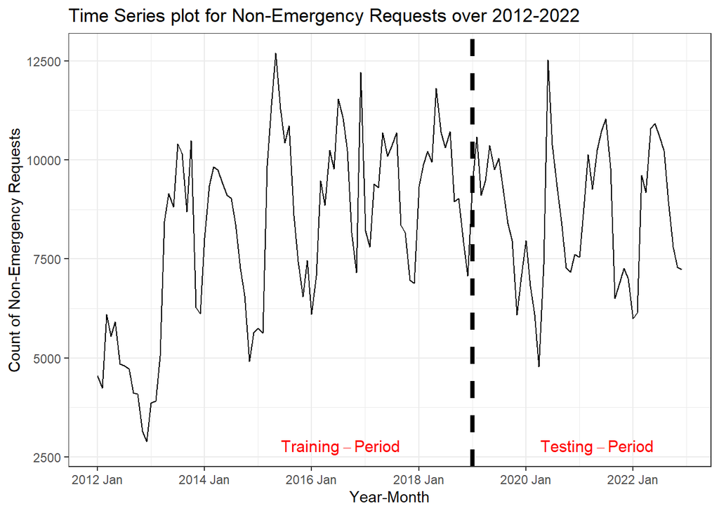

```r
data_mod_initial<-req_df %>%
  dplyr::select(REQUESTED_DATE) %>%
  mutate(DateTime = yearmonth(as.yearmon(mdy_hms(REQUESTED_DATE),"%m%Y"))) %>%
  group_by(DateTime) %>%
  summarise(Freq = n()) %>%
  arrange(DateTime) %>%
  as_tsibble(index = DateTime)

data_mod_initial <- data_mod_initial[-133,] #removing 2023 Jan data due to incompleteness

#Line Chart of entire dataset
data_mod_initial%>%
  ggplot(aes(x=DateTime,y=Freq))+
  geom_line()+
  labs(title = "Time Series plot for Non-Emergency Requests over 2012-2022",
       y = "Count of Non-Emergency Requests",
       x = "Year-Month")+
  geom_vline(xintercept=as.numeric(as.Date("2019-01-01")), color="black",
             linetype = 2, lwd = 1.5)+
  annotate("text", x=17000, y=2750, label= "Training-Period",
           col="red", size=4, parse=TRUE)+
  annotate("text", x=18750, y=2750, label= "Testing-Period",
           col="red", size=4, parse=TRUE)+
  theme_bw()
```

## Exploratory Data Analysis

#### 1. Splitting data into training and testing

#### 2. Visualizing the data

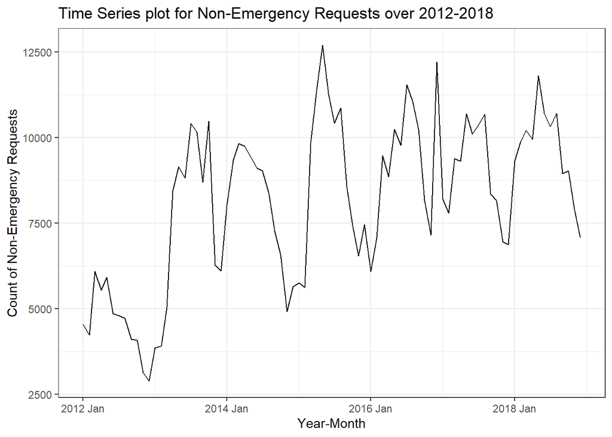

```r
#Line Chart
data_mod%>%
  ggplot(aes(x=DateTime,y=Freq))+
  geom_line()+
  labs(title = "Time Series plot for Non-Emergency Requests over 2012-2018",
       y = "Count of Non-Emergency Requests",
       x = "Year-Month") + theme_bw()
```

> This line chart shows the number of non-Emergency requests over time. It clearly shows the seasonality of the data with higher numbers of requests during summer and lower numbers of requests during winter.

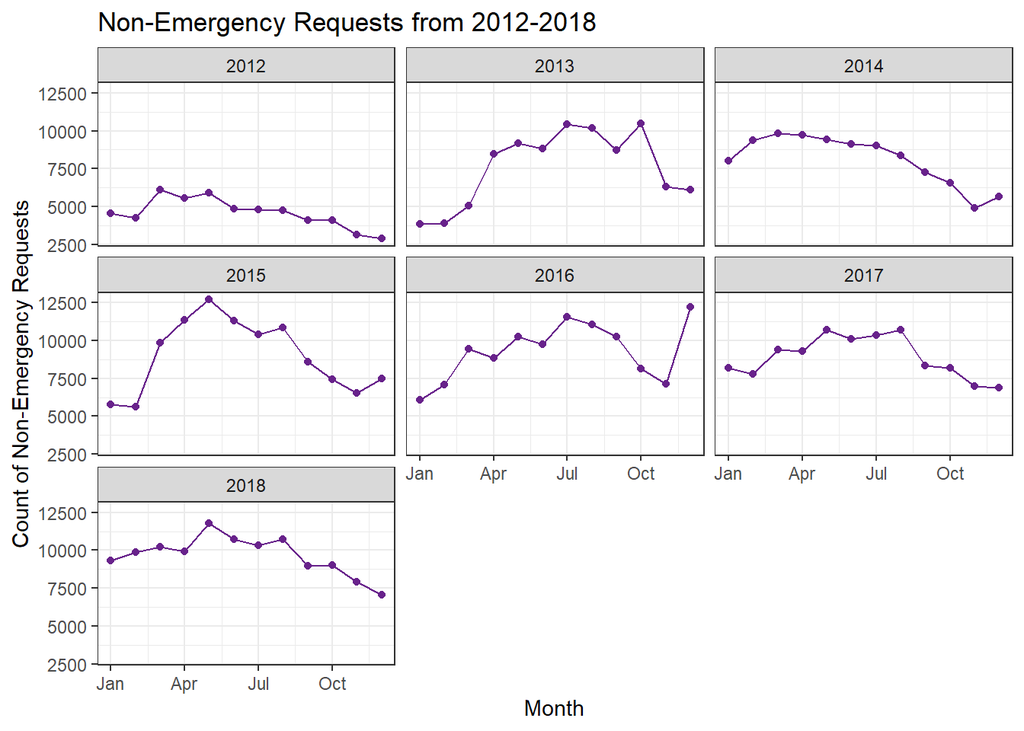

```r
train %>%
  dplyr::select(REQUESTED_DATE)%>%
  mutate(DATE = as.Date(REQUESTED_DATE, format = "%m/%d/%Y")) %>%
  count(DATE) %>%
  group_by(month = lubridate::month(DATE), year= lubridate::year(DATE)) %>%
  summarise(total = sum(n)) %>%
  filter(year != 2023) %>%
  ggplot(aes(x = month, y = total)) +
  geom_line(color = "darkorchid4")+
  geom_point(color = "darkorchid4")+
  facet_wrap(~ year, ncol = 3) +
  labs(title = "Non-Emergency Requests from 2012-2018",
       y = "Count of Non-Emergency Requests",
       x = "Month") + theme_bw() +
  scale_x_continuous(breaks = c(1,4,7,10),
                     labels = c("Jan","Apr","Jul","Oct"))
```

> The above plot shows the monthly trend across different years. This is in accordance with the previous plot to suggest that post the winter months, the frequency of requests increases.

```r
#training data summary stats

summary(data_mod$Freq)
```

```
   Min. 1st Qu.  Median    Mean 3rd Qu.    Max.
   2897    6241    8646    8170   10116   12703
```

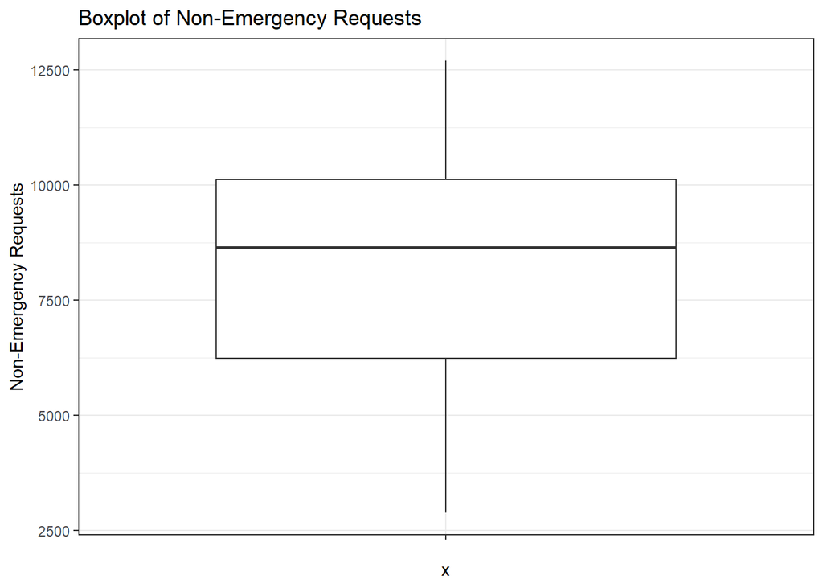

```r
#Boxplot
data_mod %>%
  ggplot(aes(x = "", y = Freq)) +
  geom_boxplot() +
  ggtitle("Boxplot of Non-Emergency Requests") +
  xlab("x") +
  ylab("Non-Emergency Requests")+
  theme_bw()
```

> This boxplot shows the distribution of the number of service requests. It helps to identify any outliers in the data, which for this dataset aren’t any.

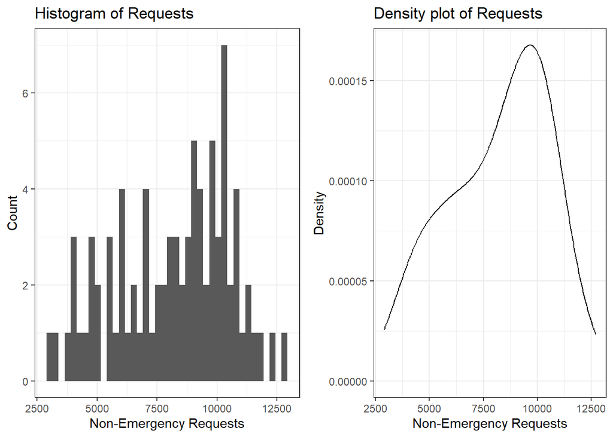

```r
# Histogram
p1<-data_mod %>%
  ggplot(aes(Freq)) +
  geom_histogram(bins = 40)+
  theme_bw()+
  ggtitle("Histogram of Requests") +
  xlab("Non-Emergency Requests") +
  ylab("Count")+
  theme_bw()

#density plot
p2<-data_mod %>%
  ggplot(aes(x = Freq)) +
  geom_density() +
  ggtitle("Density plot of Requests") +
  xlab("Non-Emergency Requests") +
  ylab("Density")+
  theme_bw()

grid.arrange(p1, p2, ncol = 2)
```

> The histogram and density plot shows the frequency of the number of service requests. It helps to identify the most common values and the spread of the data, which is mostly between 5000 to 11000.

#### 3. Summary Statistics of the data

```r
# Create a table with summary statistics

# summary_table <- (describe(data_mod$Freq))
# summary_table

summary <- data.frame(
Observations = length(data_mod$Freq),
Mean = mean(data_mod$Freq),
Median = median(data_mod$Freq),
Mode = names(which.max(table(data_mod$Freq))),
Std_Dev = sd(data_mod$Freq),
Range = range(data_mod$Freq))

kable(summary)
```

| Observations | Mean | Median | Mode | Std_Dev | Range |
| --- | --- | --- | --- | --- | --- |
| 84 | 8169.619 | 8646.5 | 7080 | 2367.843 | 2897 |
| 84 | 8169.619 | 8646.5 | 7080 | 2367.843 | 12703 |

**Inference**

Based on the analysis of the data:

- There are no outliers
- The average number of requests is 8169

This is in concurrence with the above visualizations

## Time Series Decomposition

```r
Requests_MA <- data_mod %>%
  dplyr::select(DateTime, srate = Freq) %>%
  mutate(srate_ma05 = rollmean(srate, k = 35, fill = NA, align = "center"))
```

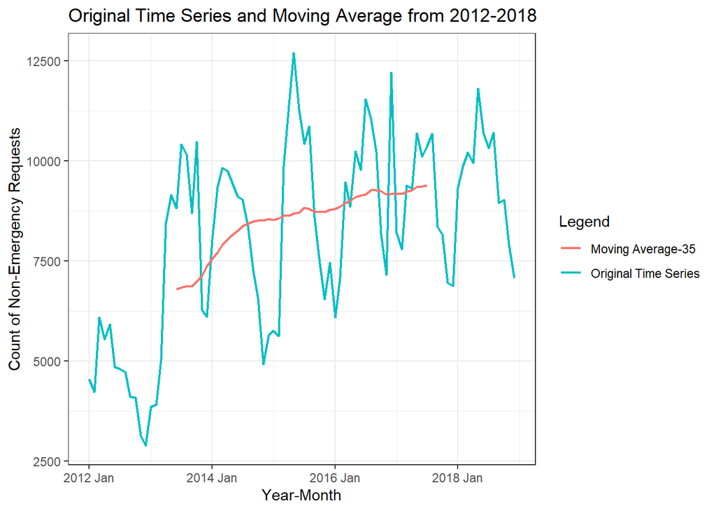

```r
# Plot original time series and moving average
ggplot() +
  geom_line(aes(x = Requests_MA$DateTime, y = Requests_MA$srate, color = "Original Time Series"), size = 0.75) +
  geom_line(aes(x = Requests_MA$DateTime, y = Requests_MA$srate_ma05, color = "Moving Average-35"), size = 0.75)  +
  labs(title = "Original Time Series and Moving Average from 2012-2018",
       y = "Count of Non-Emergency Requests",
       x = "Year-Month",
       colour = "Legend")+
  theme_bw()
```

> Post testing different moving averages, it was determined that Moving Average-35 represented the time series trend well.

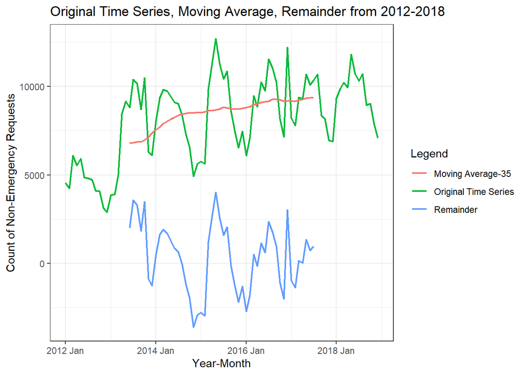

```r
# Remainder
Requests_MA$remainder <- Requests_MA$srate - Requests_MA$srate_ma05

# Plot original time series, moving average and remainder
ggplot() +
  geom_line(aes(x = Requests_MA$DateTime, y = Requests_MA$srate, color = "Original Time Series"), size = 0.75) +
  geom_line(aes(x = Requests_MA$DateTime, y = Requests_MA$srate_ma05, color = "Moving Average-35"), size = 0.75) +
  geom_line(aes(x = Requests_MA$DateTime, y = Requests_MA$remainder, color = "Remainder"), size = 0.75)  +
  labs(title = "Original Time Series, Moving Average, Remainder from 2012-2018",
       y = "Count of Non-Emergency Requests",
       x = "Year-Month",
       colour = "Legend")+
  theme_bw()
```

> It does appear that remainder may have certain pattern or seasonality that wasn’t interpretative from the moving average. However, further analysis may be required.

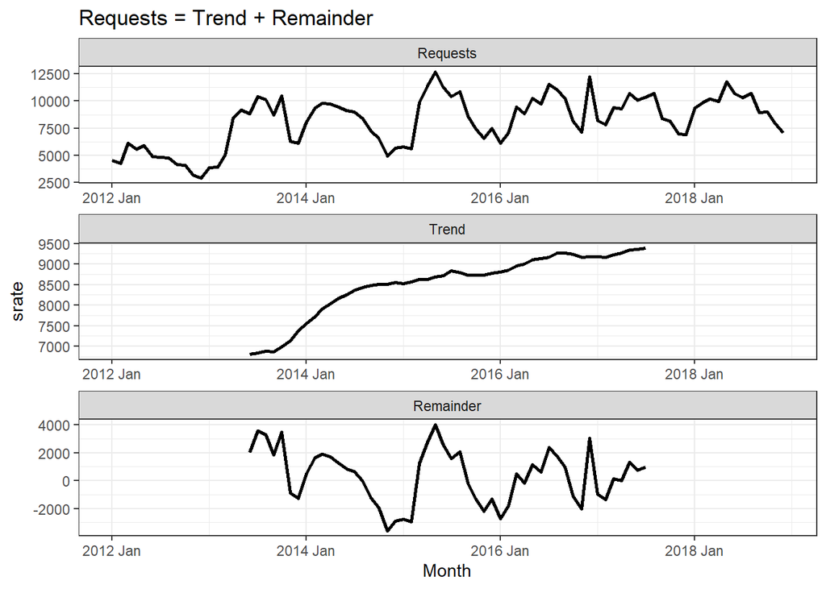

```r
#Decomposition
Requests_MA_decomp <- Requests_MA%>%
  dplyr::select(DateTime, srate, srate_ma05,remainder)

Requests_MA_decomp_plot <- Requests_MA_decomp %>%
  pivot_longer(
    srate:remainder,
    names_to = "decomposition",
    values_to = "srate"
  ) %>%
  mutate(
    decomposition = case_when(
      decomposition == "srate" ~ "Requests",
      decomposition == "srate_ma05" ~ "Trend",
      decomposition == "remainder" ~ "Remainder"
    )
  ) %>%
  mutate(
    decomposition = factor(
      decomposition,
      labels = c(
        "Requests",
        "Trend",
        "Remainder"
      ),
      levels = c(
        "Requests",
        "Trend",
        "Remainder"
      )
    )
  ) %>%
  ggplot() +
  geom_line(aes(DateTime, srate), size = 1) +
  facet_wrap(
    ~decomposition,
    nrow = 3,
    scales = "free"
  ) +
  theme_bw() +
  xlab("Month") +
  ggtitle(
    "Requests = Trend + Remainder"
  )

Requests_MA_decomp_plot
```

> Upon observing the remainder component, there appears to be a weak seasonality in the time series, which is in accordance with the expectation.

We can decompose the time series further to look for any seasonality that may exist.

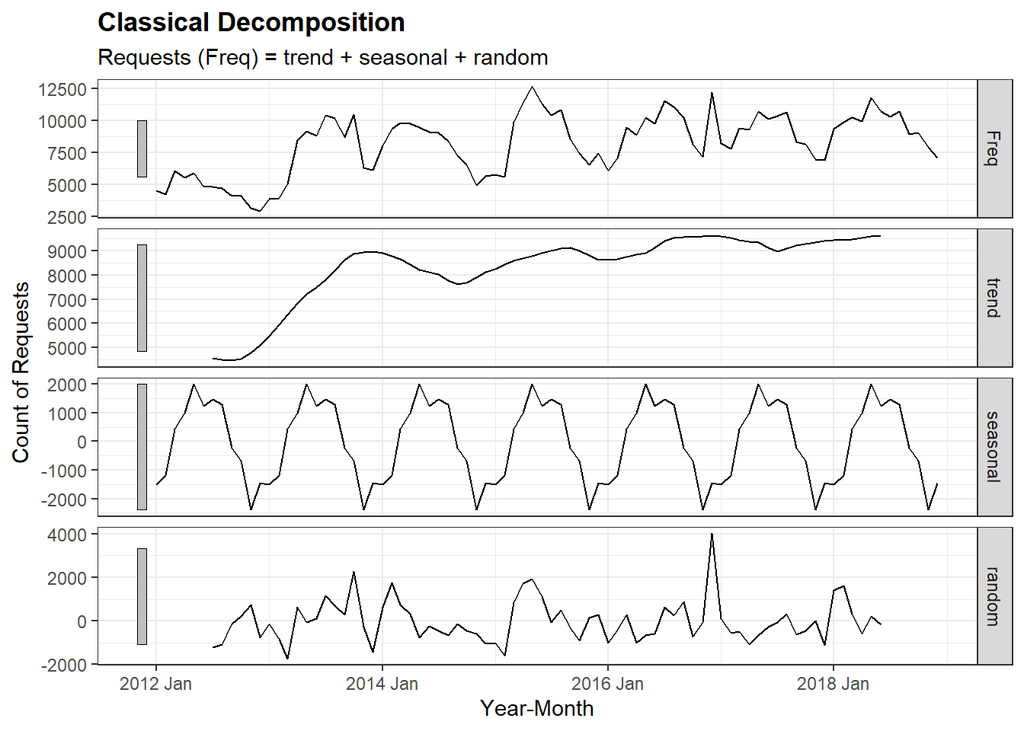

```r
data_mod%>%
  model(classical_decomposition(Freq)) %>%
  components() %>%
  autoplot() +
  theme_bw() +
  theme(
    plot.title = element_text(face = "bold"),
    plot.background = element_rect(fill = "white") )+
  labs(title = "Classical Decomposition",
       subtitle = "Requests (Freq) = trend + seasonal + random",
       y = "Count of Requests",
       x = "Year-Month")
```

> As is evident from the seasonal component above, it is clear that there exists seasonality within the time series. The remainder or random now appears to be mostly white noise with no seeming pattern.

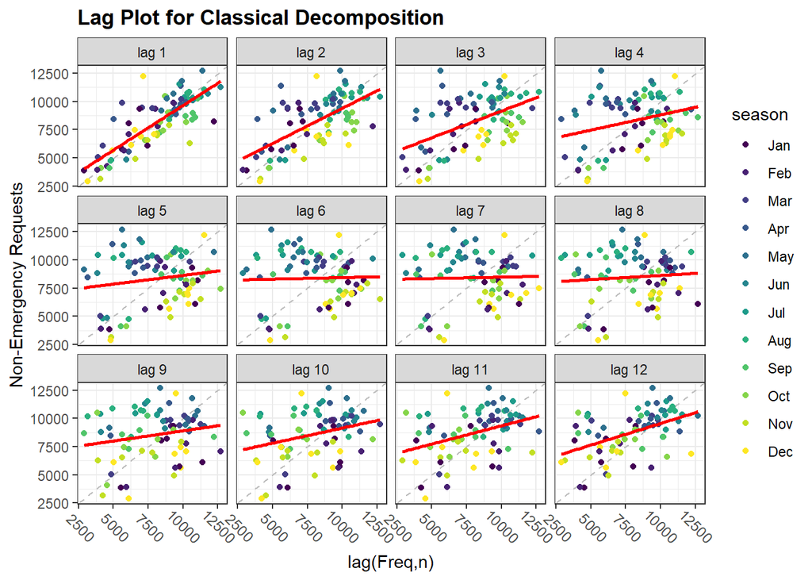

```r
#Lag plots
classical_decomp <- data_mod %>%
 model(
    classical_decomposition(Freq,"additive")
  ) %>%
  components()

stl_decomp <- data_mod %>%
  model(
    STL(Freq)
  ) %>%
  components()

classical_decomp %>%
  gg_lag(Freq, geom = "point", lags = 1:12)+
  geom_smooth(aes(color=NULL),method='lm',color='red',se=F)+
  theme_bw() +
  theme(
    plot.title = element_text(face = "bold"),
    axis.text.x = element_text(size = 9, angle = 315, vjust = -0.5, hjust=0.75),
    axis.text.y = element_text(),
    plot.background = element_rect(fill = "white") )+
  labs(title = "Lag Plot for Classical Decomposition",
       y = "Non-Emergency Requests",
       x = "lag(Freq,n)")
```

**Inference**

Based upon the decomposed time series, it has been noted:

- Time series appears to have weak seasonality
- Previous time period or lag 1 influences the data point

## ARIMA Model

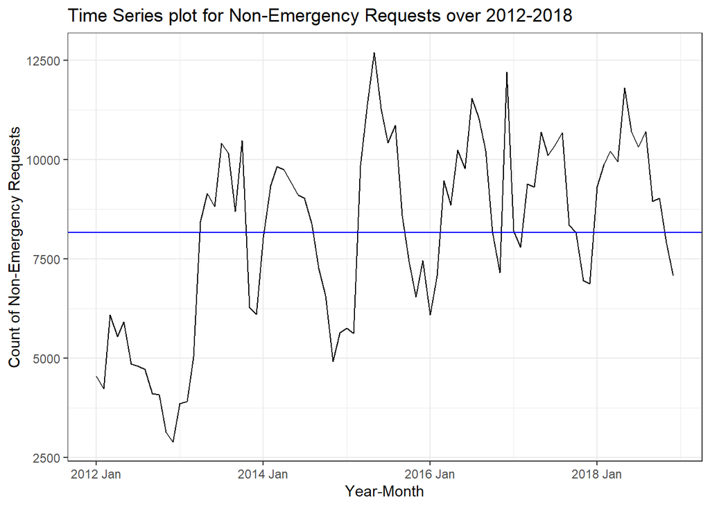

```r
#Line Chart
data_mod%>%
  ggplot(aes(x=DateTime,y=Freq))+
  geom_line()+
  geom_hline(yintercept=mean(data_mod$Freq), col = 'blue')+
  labs(title = "Time Series plot for Non-Emergency Requests over 2012-2018",
       y = "Count of Non-Emergency Requests",
       x = "Year-Month") + theme_bw()
```

> Looking at the above time series graphic, it can be said that the data is stationary, in both mean and variance. The blue line indicates the mean and thus, it can be observed that the time series is mean-reverting with the peaks and lows returning back to the average over time.

### 1. Variance Stationarity using Rolling Window

Further, an assessment of variance stationarity can be conducted using different rolling windows. We observed that the higher the rolling window, the more induced non-stationarity is observed. However, since this is a 10-year dataset, a 7 month rolling window could be observed.

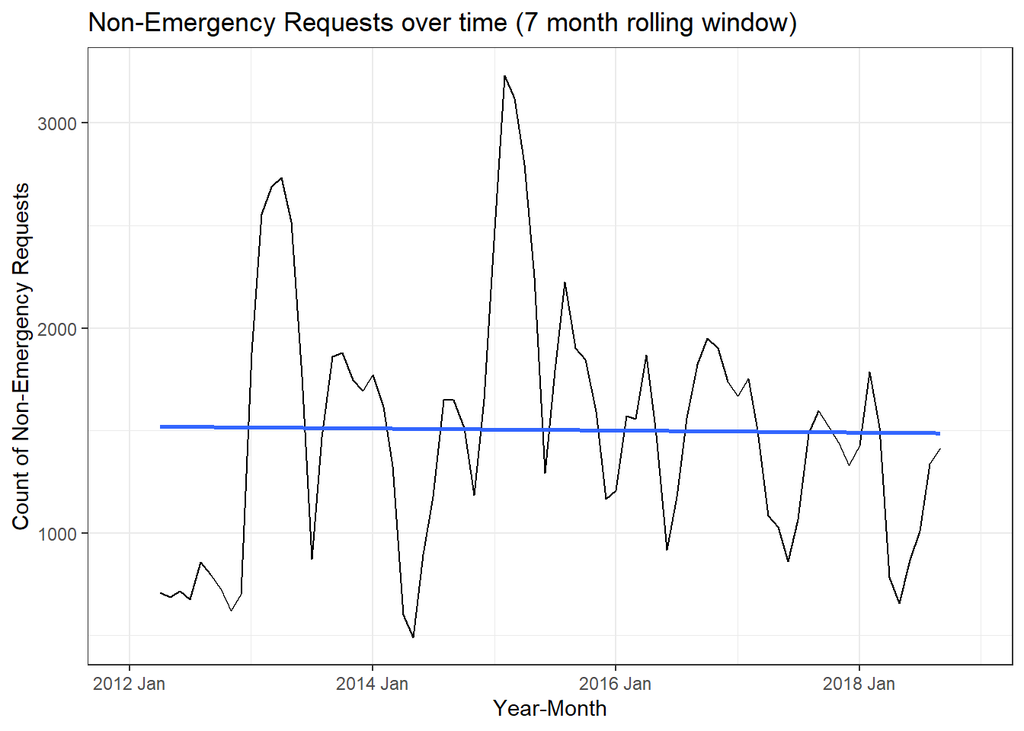

```r
data_mod_roll <- data_mod %>%
  mutate(
    freq_mean = zoo::rollmean(
      Freq,
      k = 7,
      fill = NA),
    freq_sd = zoo::rollapply(
      Freq,
      FUN = sd,
      width = 7,
      fill = NA)
  )
data_modsd <- data_mod_roll%>%
  ggplot() +
  geom_line(aes(DateTime, freq_sd)) +
  geom_smooth(aes(DateTime,freq_sd),method='lm',se=F)+
  theme_bw() +
  ggtitle("Non-Emergency Requests over time (7 month rolling window)") +
  ylab("Count of Non-Emergency Requests") +
  xlab("Year-Month")

data_modsd
```

> The above plot shows that the data is variance stationary.

> This is in accordance with the visual inference from the original time series plot, wherein it appeared to be both mean and variance stationary.

### 2. Mean Stationarity using KPSS & ADF tests

We can even verify this using statistical tests such as KPSS and Augmented Dickey-Fuller tests.

```r
data_mod %>%
  features(Freq, unitroot_kpss)
```

```
# A tibble: 1 × 2
  kpss_stat kpss_pvalue
      <dbl>       <dbl>
1     0.919        0.01
```

```r
adf.test(data_mod$Freq)
```

```
    Augmented Dickey-Fuller Test

data:  data_mod$Freq
Dickey-Fuller = -4.0033, Lag order = 4, p-value = 0.01344
alternative hypothesis: stationary
```

> Since p-value is <0.05 for the KPSS test, we consider that the time series is mean non-stationary. But p-value is <0.05 for ADF test, it indicates that the time series is mean stationary.

> We consider the results of both the tests and conclude that the time series is stationary. This is in accordance with the visual inference from the original time series plot, wherein it appeared to be both mean and variance stationary.

**Note**

Had the time series been mean or variance non-stationary, Box-Cox or Log transformations would have been conducted, which for this time series are avoidable.

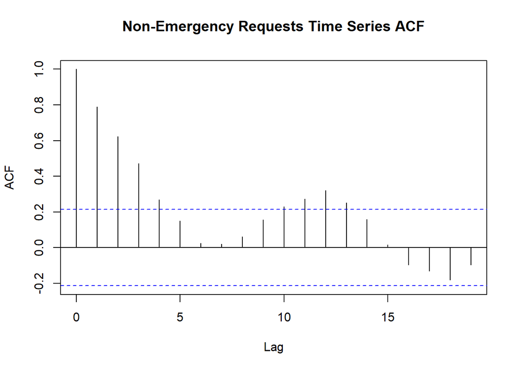

```r
ACF1 <- acf(data_mod$Freq, plot=FALSE)
plot(ACF1, main = "Non-Emergency Requests Time Series ACF")
```

> As can be noted from the above ACF plot, there appears to be weak seasonality in the time series, which exists at lag 12. Therefore, we would difference it to reduce the impact of the same.

### 3. Seasonal differencing

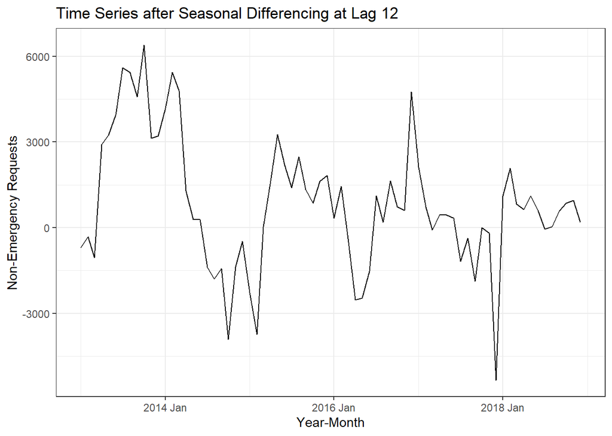

```r
# Perform seasonal differencing
data_mod['seasonal_diff'] <- as.data.frame(difference(data_mod$Freq, lag = 12))
temp = data_mod[13:nrow(data_mod), ]

# Plot the time series after seasonal differencing
ggplot(data = temp,
       aes(x = DateTime,
           y = seasonal_diff)) +
  geom_line() +
  ggtitle("Time Series after Seasonal Differencing at Lag 12") +
  xlab("Year-Month") +
  ylab("Non-Emergency Requests")+
  theme_bw()
```

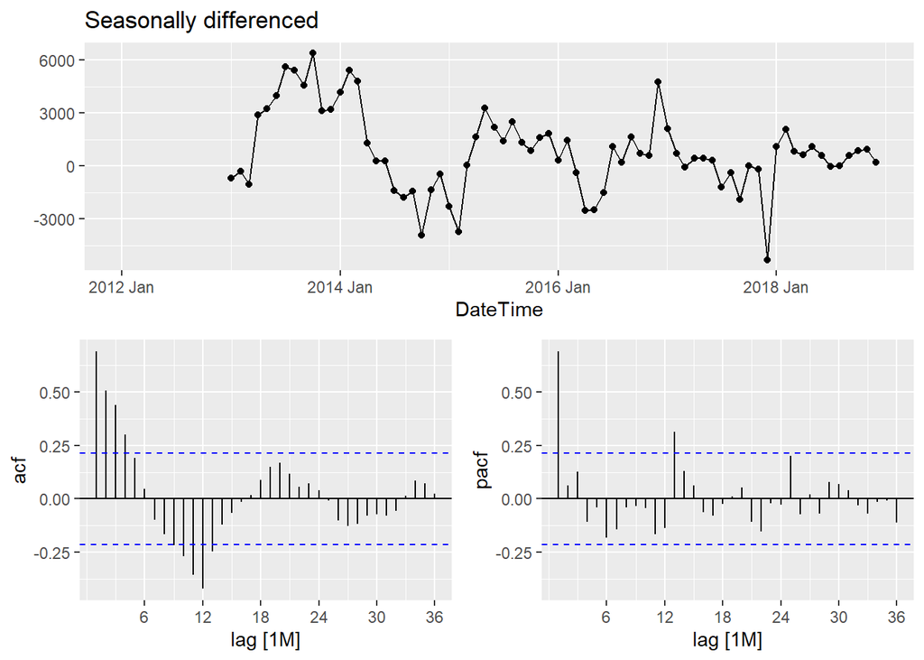

```r
data_mod %>%
  gg_tsdisplay(seasonal_diff,
               plot_type='partial', lag=36) +
  labs(title="Seasonally differenced", y="")
```

```r
data_mod %>% features(seasonal_diff, unitroot_kpss)
```

```
# A tibble: 1 × 2
  kpss_stat kpss_pvalue
      <dbl>       <dbl>
1     0.332         0.1
```

```r
adf.test(temp$seasonal_diff)
```

```
    Augmented Dickey-Fuller Test

data:  temp$seasonal_diff
Dickey-Fuller = -2.7357, Lag order = 4, p-value = 0.2758
alternative hypothesis: stationary
```

> Since p-value is >0.05 for the KPSS test, we consider that the time series is mean stationary. But p-value is >0.05 for ADF test, it indicates that the time series is mean non-stationary.

> We consider the results of both the tests and conclude that the time series is stationary.

### 4. ACF/PACF plots

Now, we can examine the ACF/PACF plots for assessment of potential ARIMA models to fit on this data.

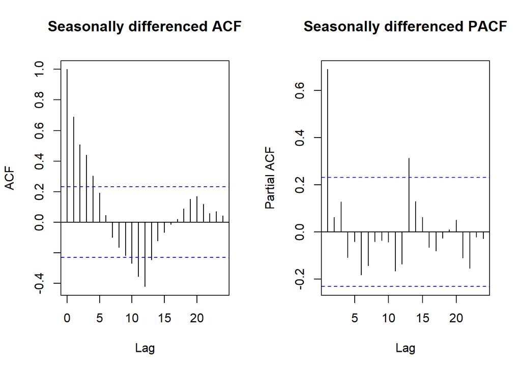

```r
par(mfrow = c(1,2))

ACF2<- acf(temp$seasonal_diff, lag.max = 24, plot=FALSE)
plot(ACF2, main = "Seasonally differenced ACF")

PACF2<- pacf(temp$seasonal_diff, lag.max = 24, plot=FALSE)
plot(PACF2, main = "Seasonally differenced PACF")
```

> As per the ACF plot, there appears to be a diminishing effect. Hence, we can conclude that this is an AR process. The PACF plot suggests that the order could be 1.

> It can be inferred that this time series is ARIMA(1,1,0). Since there exists weak seasonality as well at lag 12, there may also exist seasonal ARIMA effects of the order (0,1,0).

```r
# Order = p,d,q (AR, I, MA)
models_bic = data_mod %>%
  model(
    mod1 = ARIMA(Freq~pdq(1,0,0)+PDQ(0,1,0)),
    mod2 = ARIMA(Freq~pdq(1,1,1)+PDQ(0,1,0)),
    mod3 = ARIMA(Freq~pdq(1,1,0)+PDQ(0,1,0)),
    mod4 = ARIMA(Freq~pdq(2,1,0)+PDQ(0,1,0)),
    mod5 = ARIMA(Freq~pdq(2,1,1)+PDQ(0,1,0)),
    mod6 = ARIMA(Freq~pdq(2,0,0)+PDQ(0,1,0))
    )


models_bic%>%
  glance() %>%
  arrange(BIC)
```

```
# A tibble: 6 × 8
  .model   sigma2 log_lik   AIC  AICc   BIC ar_roots  ma_roots
  <chr>     <dbl>   <dbl> <dbl> <dbl> <dbl> <list>    <list>
1 mod2   2806848.   -628. 1262. 1263. 1269. <cpl [1]> <cpl [1]>
2 mod3   3119285.   -631. 1266. 1266. 1271. <cpl [1]> <cpl [0]>
3 mod4   2981353.   -629. 1264. 1264. 1271. <cpl [2]> <cpl [0]>
4 mod5   3011976.   -629. 1266. 1266. 1275. <cpl [2]> <cpl [1]>
5 mod1   2780889.   -636. 1276. 1277. 1281. <cpl [1]> <cpl [0]>
6 mod6   2801654.   -636. 1278. 1278. 1285. <cpl [2]> <cpl [0]>
```

> It appears that ARIMA(1,1,1) model with seasonal component (0,1,0) seems to be the best according to the BIC.

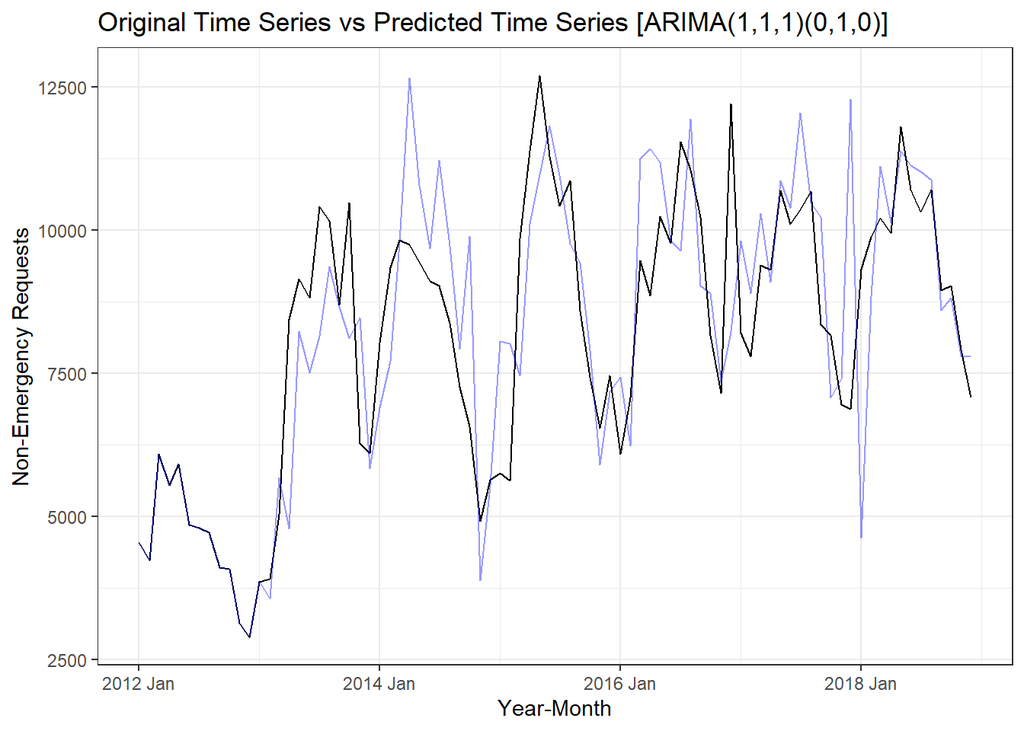

```r
best_mod = data_mod %>%
  model(ARIMA(Freq~pdq(1,1,1)+PDQ(0,1,0),approximation = F, stepwise = F))

# Get fitted values
fitted = best_mod %>%
  augment() %>%
  .$.fitted

ggplot() +
  geom_line(aes(data_mod$DateTime, data_mod$Freq)) +
  geom_line(aes(data_mod$DateTime, fitted), color = "blue", alpha = 0.4) +
  theme_bw() +
  xlab("Year-Month") +
  ylab("Non-Emergency Requests")+
  ggtitle("Original Time Series vs Predicted Time Series [ARIMA(1,1,1)(0,1,0)]")
```

> The predicted values do seem to somewhat follow the trend in the original data. However, it would be better to assess the residuals from this model as well.

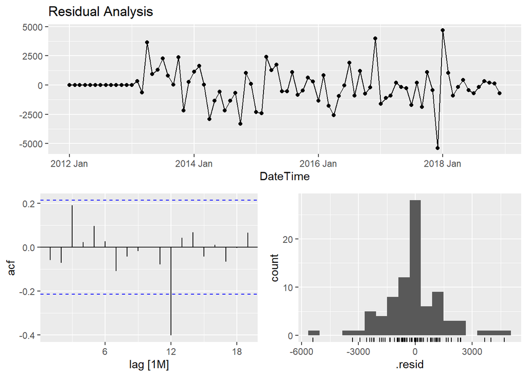

```r
best_mod %>%
  gg_tsresiduals() +
  labs(title="Residual Analysis", y="")
```

**Attention**

As we see above, Residuals show strong autocorrelation at lag 12, indicating there is not white noise, and there still exists some autocorrelation between the residuals. Hence, it is not a good idea to retain the current model.

### 5. Box-Ljung test for Residual autocorrelation

To ascertain this, we can even conduct a Box-Ljung test for autocorrelation verification in the residuals.

```r
lag1 = best_mod %>%
  augment() %>%
  features(.innov, ljung_box, lag = 1, dof = 1)

lag2 = best_mod %>%
  augment() %>%
  features(.innov, ljung_box, lag = 2, dof = 1)

lag3 = best_mod %>%
  augment() %>%
  features(.innov, ljung_box, lag = 3, dof = 1)

lag4 = best_mod %>%
  augment() %>%
  features(.innov, ljung_box, lag = 4, dof = 1)

lag5 = best_mod %>%
  augment() %>%
  features(.innov, ljung_box, lag = 5, dof = 1)

lag6 = best_mod %>%
  augment() %>%
  features(.innov, ljung_box, lag = 6, dof = 1)

lag7 = best_mod %>%
  augment() %>%
  features(.innov, ljung_box, lag = 7, dof = 1)

lag8 = best_mod %>%
  augment() %>%
  features(.innov, ljung_box, lag = 8, dof = 1)

lag9 = best_mod %>%
  augment() %>%
  features(.innov, ljung_box, lag = 9, dof = 1)

lag10 = best_mod %>%
  augment() %>%
  features(.innov, ljung_box, lag = 10, dof = 1)

lag11 = best_mod %>%
  augment() %>%
  features(.innov, ljung_box, lag = 11, dof = 1)

lag12 = best_mod %>%
  augment() %>%
  features(.innov, ljung_box, lag = 12, dof = 1)

lag13 = best_mod %>%
  augment() %>%
  features(.innov, ljung_box, lag = 13, dof = 1)


table_resid <- data.frame(lag = c(1,2,3,4,5,6,7,8,9,10,11,12,13),
                          lb_stat = c(lag1$lb_stat,lag2$lb_stat,lag3$lb_stat,lag4$lb_stat,lag5$lb_stat,lag6$lb_stat,lag7$lb_stat,lag8$lb_stat,lag9$lb_stat,lag10$lb_stat,lag11$lb_stat,lag12$lb_stat,lag13$lb_stat),
                          pvalue = c(lag1$lb_pvalue,lag2$lb_pvalue,lag3$lb_pvalue,lag4$lb_pvalue,lag5$lb_pvalue,lag6$lb_pvalue,lag7$lb_pvalue,lag8$lb_pvalue,lag9$lb_pvalue,lag10$lb_pvalue,lag11$lb_pvalue,lag12$lb_pvalue,lag13$lb_pvalue),
                          residual_autocorrelation = c(lag1$lb_pvalue < 0.05,lag2$lb_pvalue < 0.05,lag3$lb_pvalue < 0.05,lag4$lb_pvalue < 0.05,lag5$lb_pvalue < 0.05,lag6$lb_pvalue < 0.05,lag7$lb_pvalue < 0.05,lag8$lb_pvalue < 0.05,lag9$lb_pvalue < 0.05,lag10$lb_pvalue < 0.05,lag11$lb_pvalue < 0.05,lag12$lb_pvalue < 0.05,lag13$lb_pvalue < 0.05))


print(table_resid)
```

```
   lag    lb_stat     pvalue residual_autocorrelation
1    1  0.3007819 0.00000000                     TRUE
2    2  0.7444080 0.38825249                    FALSE
3    3  4.0047937 0.13501129                    FALSE
4    4  4.0527019 0.25582923                    FALSE
5    5  4.9125344 0.29639032                    FALSE
6    6  4.9789356 0.41845633                    FALSE
7    7  6.0994923 0.41213776                    FALSE
8    8  6.2754270 0.50798244                    FALSE
9    9  6.3065113 0.61293986                    FALSE
10  10  6.3065151 0.70889210                    FALSE
11  11  6.9143173 0.73350842                    FALSE
12  12 23.1773413 0.01668432                     TRUE
13  13 23.3715301 0.02473234                     TRUE
```

> Since p-value is <0.05, there appears to be residual autocorrelation at lag 1, 12 and 13. Hence, this model is not the best ARIMA model.

### 6. Automated ARIMA for best results

In order to predict the best ARIMA model, we can use the automated ARIMA tool on the original dataset.

```r
best_mod2 = data_mod %>%
  model(
    fable::ARIMA(Freq,approximation=F,
    stepwise=F)
  )

best_mod2%>%
  report()
```

```
Series: Freq
Model: ARIMA(3,0,0)(2,1,0)[12]

Coefficients:
         ar1      ar2     ar3     sar1     sar2
      0.6523  -0.0780  0.2783  -0.6573  -0.3086
s.e.  0.1173   0.1451  0.1196   0.1269   0.1384

sigma^2 estimated as 1951177:  log likelihood=-624.32
AIC=1260.64   AICc=1261.93   BIC=1274.3
```

> In a summary, *ARIMA(3,0,0)(2,1,0)[12]* is a type of ARIMA model that considers the past three values and the past two values of the seasonal component for its predictions.

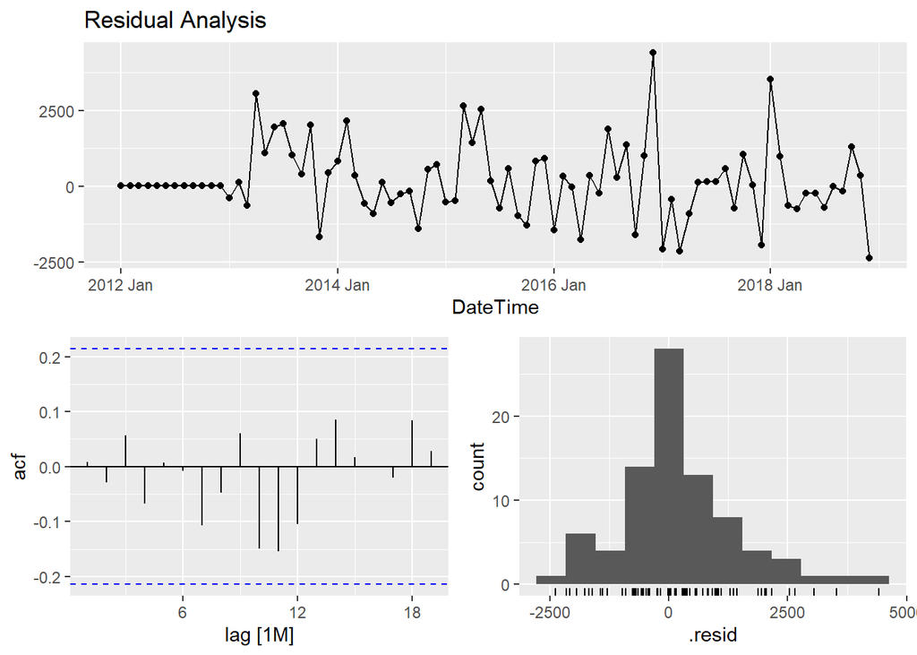

```r
best_mod2 %>%
  gg_tsresiduals() +
  labs(title="Residual Analysis", y="")
```

> The residuals do suggest white noise for the model suggested above i.e. ARIMA(3,0,0)(2,1,0). We can also validate this statistically with the Box-Ljung test.

```r
lag_1 = best_mod2 %>%
  augment() %>%
  features(.innov, ljung_box, lag = 1, dof = 1)

lag_2 = best_mod2 %>%
  augment() %>%
  features(.innov, ljung_box, lag = 2, dof = 1)

lag_3 = best_mod2 %>%
  augment() %>%
  features(.innov, ljung_box, lag = 3, dof = 1)

lag_4 = best_mod2 %>%
  augment() %>%
  features(.innov, ljung_box, lag = 4, dof = 1)

lag_5 = best_mod2 %>%
  augment() %>%
  features(.innov, ljung_box, lag = 5, dof = 1)

lag_6 = best_mod2 %>%
  augment() %>%
  features(.innov, ljung_box, lag = 6, dof = 1)

lag_7 = best_mod2 %>%
  augment() %>%
  features(.innov, ljung_box, lag = 7, dof = 1)

lag_8 = best_mod2 %>%
  augment() %>%
  features(.innov, ljung_box, lag = 8, dof = 1)

lag_9 = best_mod2 %>%
  augment() %>%
  features(.innov, ljung_box, lag = 9, dof = 1)

lag_10 = best_mod2 %>%
  augment() %>%
  features(.innov, ljung_box, lag = 10, dof = 1)

lag_11 = best_mod2 %>%
  augment() %>%
  features(.innov, ljung_box, lag = 11, dof = 1)

lag_12 = best_mod2 %>%
  augment() %>%
  features(.innov, ljung_box, lag = 12, dof = 1)

lag_13 = best_mod2 %>%
  augment() %>%
  features(.innov, ljung_box, lag = 13, dof = 1)


table_resid2 <- data.frame(lag = c(1,2,3,4,5,6,7,8,9,10,11,12,13),
                          lb_stat = c(lag_1$lb_stat,lag_2$lb_stat,lag_3$lb_stat,lag_4$lb_stat,lag_5$lb_stat,lag_6$lb_stat,lag_7$lb_stat,lag_8$lb_stat,lag_9$lb_stat,lag_10$lb_stat,lag_11$lb_stat,lag_12$lb_stat,lag_13$lb_stat),
                          pvalue = c(lag_1$lb_pvalue,lag_2$lb_pvalue,lag_3$lb_pvalue,lag_4$lb_pvalue,lag_5$lb_pvalue,lag_6$lb_pvalue,lag_7$lb_pvalue,lag_8$lb_pvalue,lag_9$lb_pvalue,lag_10$lb_pvalue,lag_11$lb_pvalue,lag_12$lb_pvalue,lag_13$lb_pvalue),
                          residual_autocorrelation = c(lag_1$lb_pvalue < 0.05,lag_2$lb_pvalue < 0.05,lag_3$lb_pvalue < 0.05,lag_4$lb_pvalue < 0.05,lag_5$lb_pvalue < 0.05,lag_6$lb_pvalue < 0.05,lag_7$lb_pvalue < 0.05,lag_8$lb_pvalue < 0.05,lag_9$lb_pvalue < 0.05,lag_10$lb_pvalue < 0.05,lag_11$lb_pvalue < 0.05,lag_12$lb_pvalue < 0.05,lag_13$lb_pvalue < 0.05))


knitr::kable(print(table_resid2))
```

```
   lag     lb_stat    pvalue residual_autocorrelation
1    1 0.006620199 0.0000000                     TRUE
2    2 0.078240130 0.7796967                    FALSE
3    3 0.361412372 0.8346806                    FALSE
4    4 0.774777219 0.8554900                    FALSE
5    5 0.779187877 0.9412162                    FALSE
6    6 0.784878828 0.9779878                    FALSE
7    7 1.850051202 0.9329597                    FALSE
8    8 2.059224551 0.9564898                    FALSE
9    9 2.415654795 0.9655481                    FALSE
10  10 4.576624613 0.8695449                    FALSE
11  11 6.928573115 0.7321704                    FALSE
12  12 8.022296366 0.7113052                    FALSE
13  13 8.280054394 0.7628800                    FALSE
```

| lag | lb_stat | pvalue | residual_autocorrelation |
| --- | --- | --- | --- |
| 1 | 0.0066202 | 0.0000000 | TRUE |
| 2 | 0.0782401 | 0.7796967 | FALSE |
| 3 | 0.3614124 | 0.8346806 | FALSE |
| 4 | 0.7747772 | 0.8554900 | FALSE |
| 5 | 0.7791879 | 0.9412162 | FALSE |
| 6 | 0.7848788 | 0.9779878 | FALSE |
| 7 | 1.8500512 | 0.9329597 | FALSE |
| 8 | 2.0592246 | 0.9564898 | FALSE |
| 9 | 2.4156548 | 0.9655481 | FALSE |
| 10 | 4.5766246 | 0.8695449 | FALSE |
| 11 | 6.9285731 | 0.7321704 | FALSE |
| 12 | 8.0222964 | 0.7113052 | FALSE |
| 13 | 8.2800544 | 0.7628800 | FALSE |

> Since p-value is <0.05, there appears to be residual autocorrelation at lag 1 only.

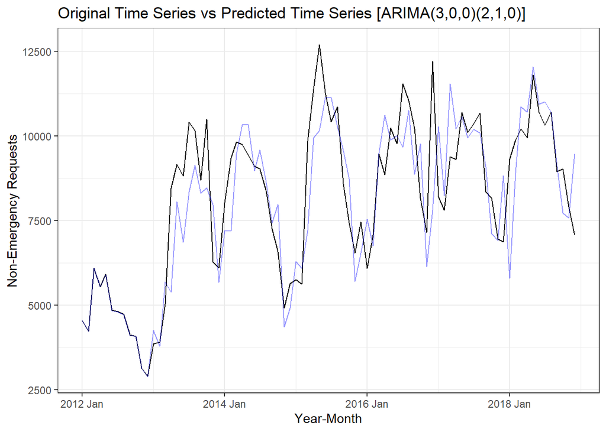

```r
# Get fitted values
fitted2 = best_mod2 %>%
  augment() %>%
  .$.fitted

ggplot() +
  geom_line(aes(data_mod$DateTime, data_mod$Freq)) +
  geom_line(aes(data_mod$DateTime, fitted2), color = "blue", alpha = 0.4) +
  theme_bw() +
  xlab("Year-Month") +
  ylab("Non-Emergency Requests")+
  ggtitle("Original Time Series vs Predicted Time Series [ARIMA(3,0,0)(2,1,0)]")
```

> However, the forecast seems very reasonable to have followed the trends and patterns of the original time series very closely. Hence, the *model ARIMA(3,0,0)(2,1,0)[12]* is good to be considered.

**Inference**

ARIMA Model suggests that:

- ARIMA(3,0,0)(2,1,0)[12] is the best for this dataset
- Residuals suggest white noise

## Meta Prophet Model

**Note**

```r
data_mod2 <- train %>%
  dplyr::select(REQUESTED_DATE) %>%
  dplyr::mutate(DateTime = as.Date(mdy_hms(REQUESTED_DATE),"%m/%d/%Y")) %>%
  group_by(DateTime) %>%
  dplyr::summarize(Freq = n()) %>%
  arrange(DateTime) %>%
  as_tsibble(index = DateTime)

prophet_data = data_mod %>%
    rename(ds = DateTime, # Have to name our date variable "ds"
    y = Freq)
```

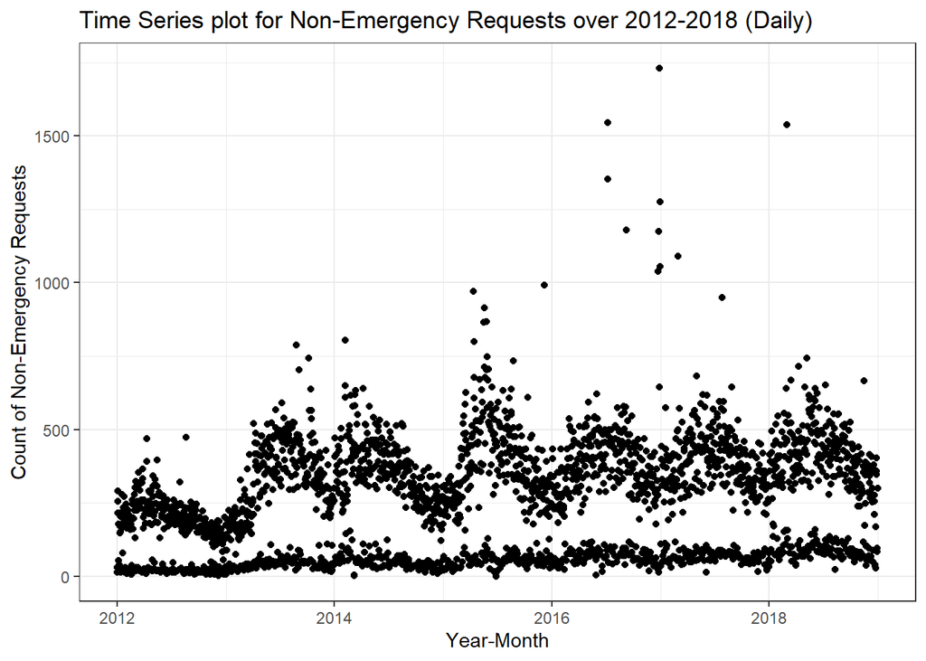

```r
#Line Chart
data_mod2%>%
  ggplot(aes(x=DateTime,y=Freq))+
  geom_point()+
  labs(title = "Time Series plot for Non-Emergency Requests over 2012-2018 (Daily)",
       y = "Count of Non-Emergency Requests",
       x = "Year-Month") + theme_bw()
```

> The best Prophet model would require the following parameters:
> - no. of changepoints and associated hyperparameters
> - growth i.e. linear/logistic
> - seasonality type i.e. additive/multiplicative

> To assess the best parameters for a best fit model, we would separately investigate how different values for the above parameters influence our model predictions. We would then compare the RMSE, MAE and MAPE statistics for each of the different parameter values. These statistics are based upon the residuals/errors, in essence.

### **1. Number of Changepoints**

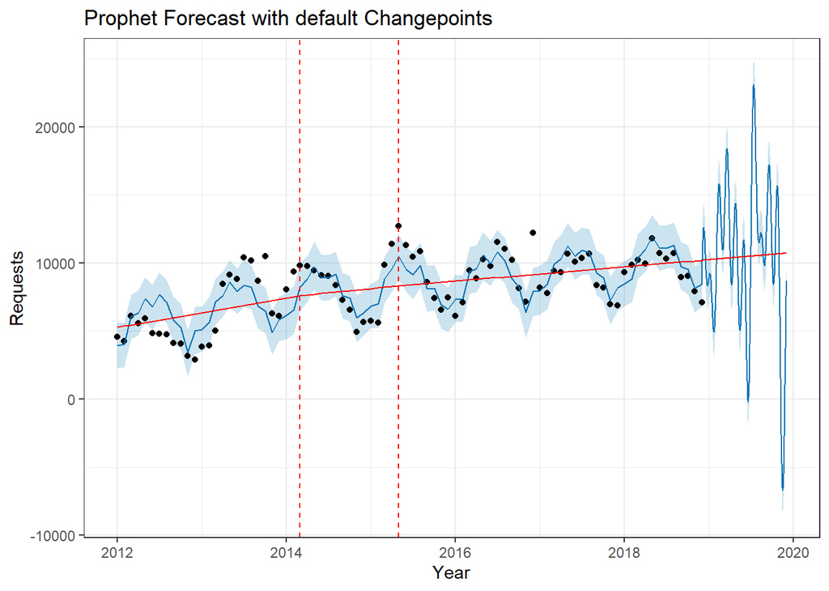

```r
# automated changepoint detection
# library(changepoint)
# cp = cpt.mean(prophet_data$y)
# print(cp)


# Number of Changepoints = 25

orig_model = prophet::prophet(prophet_data) # Train Model

orig_future = make_future_dataframe(orig_model,periods = 365, freq= 'days') # Create future dataframe for predictions

orig_forecast = predict(orig_model,orig_future) # Get forecast



plot(orig_model,orig_forecast)+
  add_changepoints_to_plot(orig_model)+
  theme_bw()+
  xlab("Year")+
  ylab("Requests")+
  ggtitle("Prophet Forecast with default Changepoints")
```

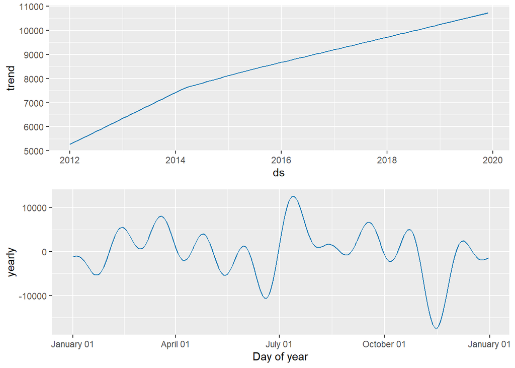

```r
prophet_plot_components(orig_model, orig_forecast)
```

> As was noted in the time-series, the frequency of requests is higher for the summer months and lower for the winter months.

### 2. Hyperparameters - Range & Flexibility

We can even change certain hyperparameters like range and flexibility to assess further.

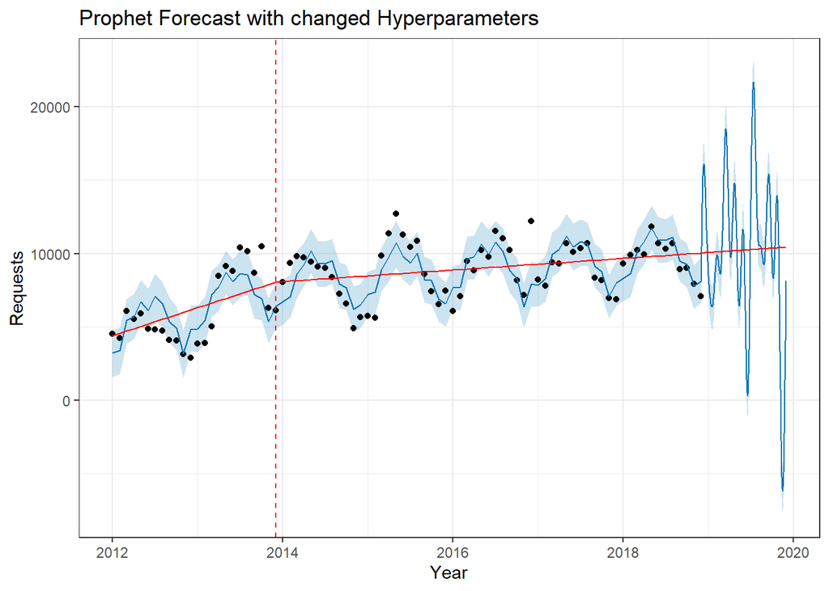

```r
# Number of Changepoints & Hyperparameters changed
model = prophet::prophet(prophet_data, n.changepoints = 15, changepoint.prior.scale = 0.09, changepoint.range = 0.7)

forecast = predict(model,orig_future)

plot(model,forecast)+
  add_changepoints_to_plot(model)+
  theme_bw()+
  xlab("Year")+
  ylab("Requests")+
  ggtitle("Prophet Forecast with changed Hyperparameters")
```

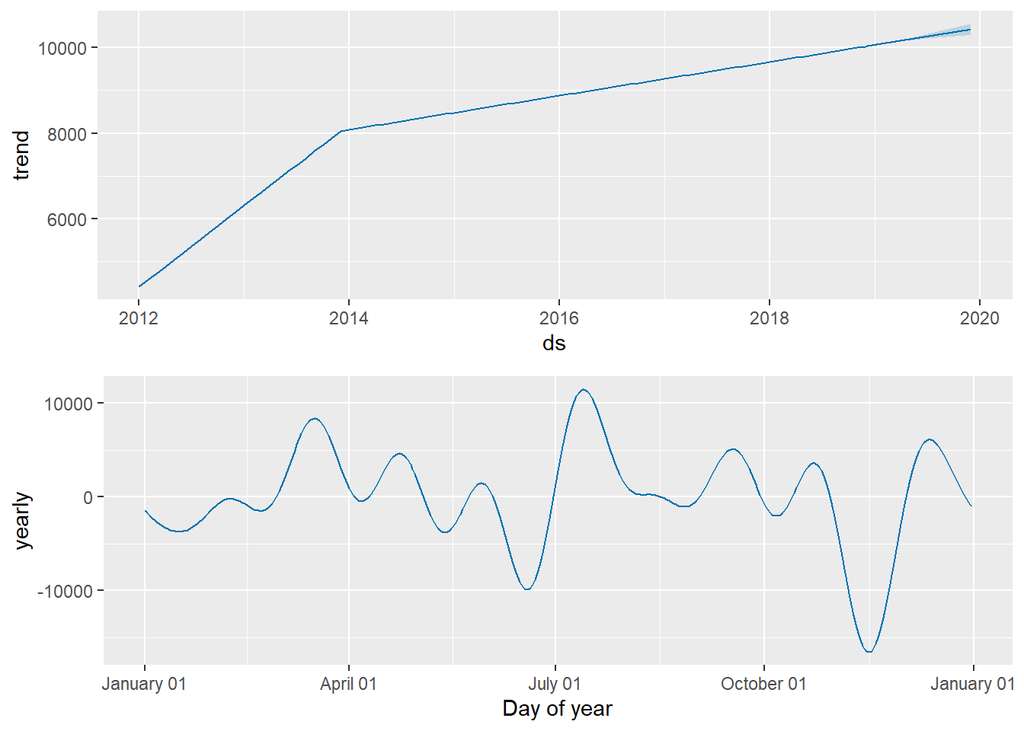

```r
prophet_plot_components(model, forecast)
```

> Upon changing the hyperparameters (n.changepoints = 15, changepoint.prior.scale = 0.09, changepoint.range = 0.7), one can note that there has been the detection of only 1 significant changepoints and a more steeper trend in the time series. Higher number of changepoints could lead to overfitting.

### 3. Saturating Points

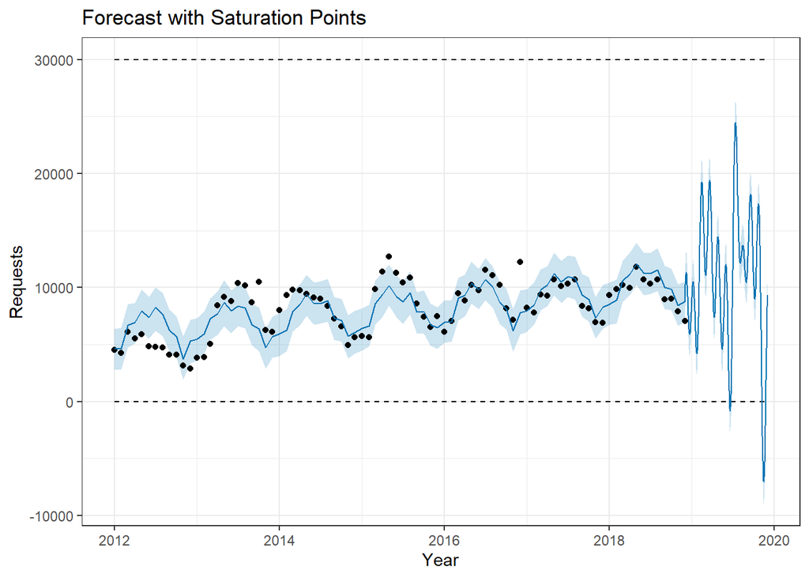

```r
# Set "floor" in training data
prophet_data$floor = 0
prophet_data$cap = 30000
orig_future$floor = 0
orig_future$cap = 30000

# Set floor in forecast data
orig_future$floor = 0
orig_future$cap = 30000

logistic_model = prophet::prophet(prophet_data,growth='logistic')

logistic_forecast = predict(logistic_model,orig_future)

plot(logistic_model,logistic_forecast)+
  # ylim(0,800)+
  theme_bw()+
  xlab("Year")+
  ylab("Requests")+
  ggtitle("Forecast with Saturation Points")
```

> Since the count of requests always has to be zero or a positive integer, a floor value has been set at 0. Alongside, a cap must also be set, which for now is at a 30,000. We have applied growth = ‘logistic’ in the model due to inclusion of floor value.

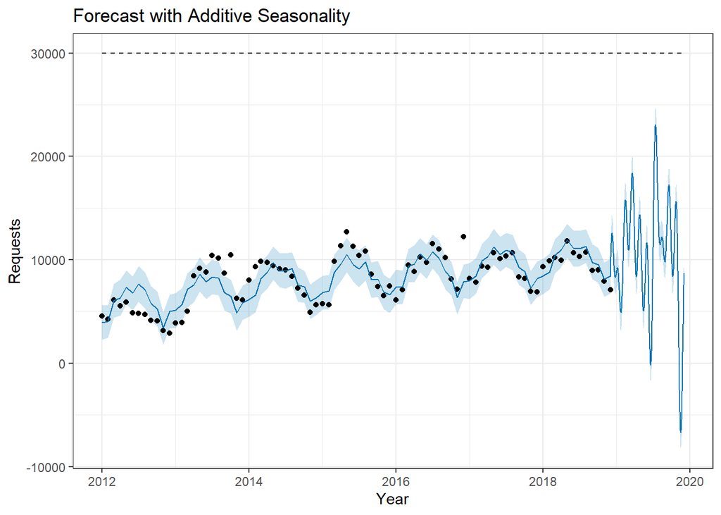

```r
additive = prophet::prophet(prophet_data)
add_fcst = predict(additive,orig_future)

plot(additive,add_fcst)+
  theme_bw()+
  xlab("Year")+
  ylab("Requests")+
  ggtitle("Forecast with Additive Seasonality")
```

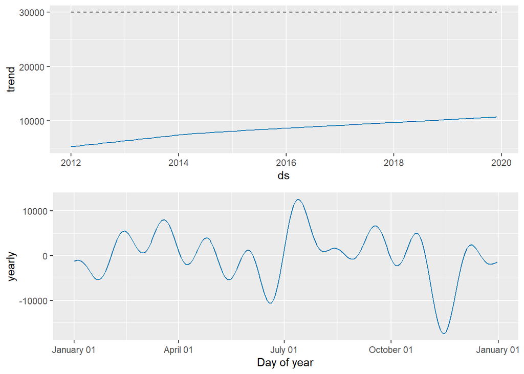

```r
prophet_plot_components(additive,add_fcst)
```

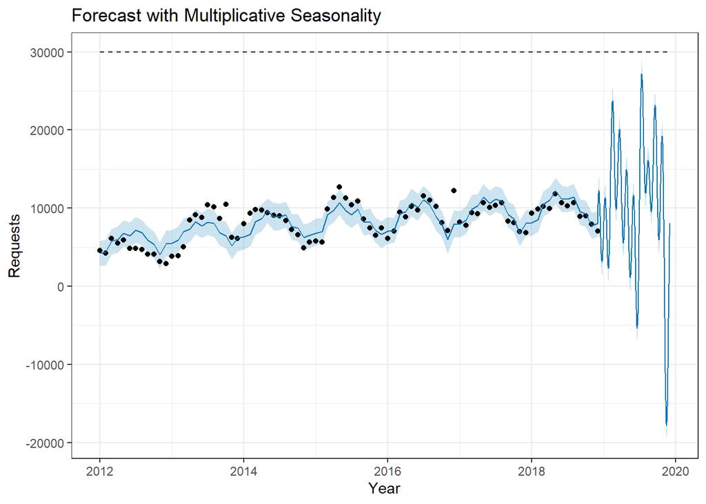

```r
multi = prophet::prophet(prophet_data,seasonality.mode = 'multiplicative')
multi_fcst = predict(multi,orig_future)

plot(multi,multi_fcst)+
  theme_bw()+
  xlab("Year")+
  ylab("Requests")+
  ggtitle("Forecast with Multiplicative Seasonality")
```

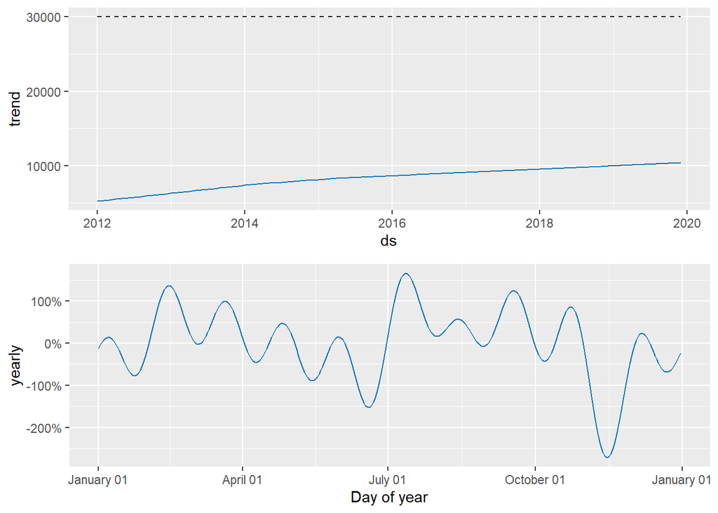

```r
prophet_plot_components(multi,multi_fcst)
```

The component plots for additive and multiplicative seasonality incorporated models do not have much difference in the components.

### 4. Holiday Data

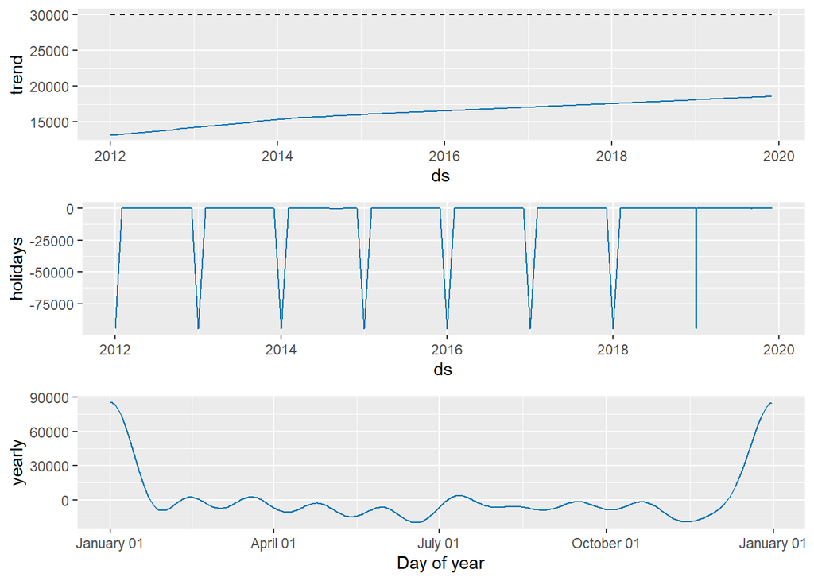

```r
model_holiday = prophet::prophet(prophet_data,fit=FALSE, seasonality.mode = 'additive')

model_holiday = add_country_holidays(model_holiday,country_name = 'US')

model_holiday = fit.prophet(model_holiday,prophet_data)

forecast_holiday = predict(model_holiday,orig_future)

prophet_plot_components(model_holiday,forecast_holiday)
```

> Considering Additive seasonality, we have incorporated the holidays data. As is visible in the holidays component, there is a drop in the number of requests once a year, atleast. We can, further, specify this holiday below.

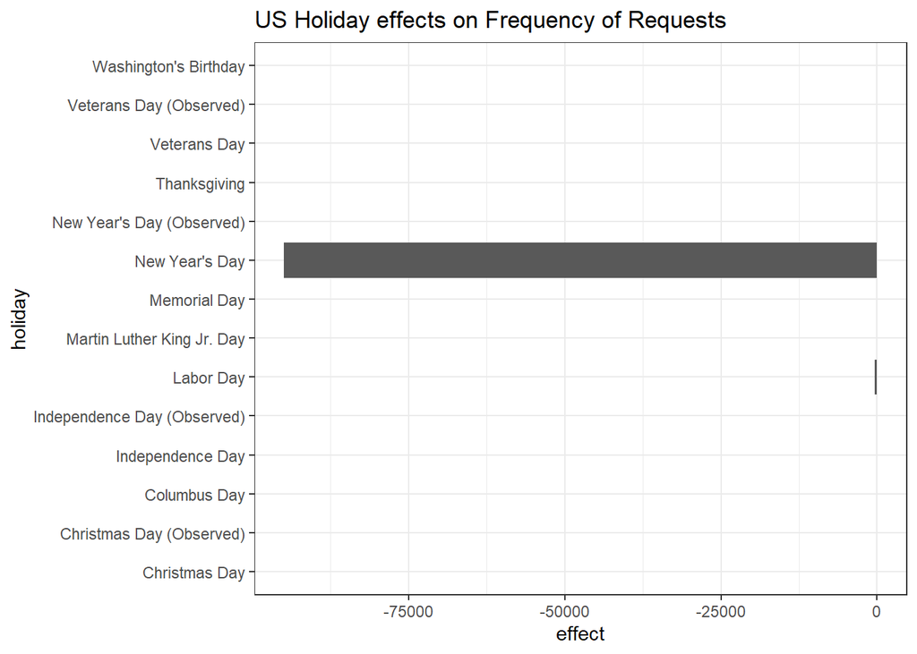

```r
forecast_holiday %>%
  filter(holidays != 0) %>%
  dplyr::select(-ds:-additive_terms_upper, -holidays:-holidays_upper, -contains("upper"), -contains("lower")) %>%
  mutate_all(~ if_else(. == 0, as.numeric(NA), .)) %>%
  summarize_if(is.numeric, ~ max(., na.rm = T)) %>%
  pivot_longer(
    cols = `Christmas Day`:`Washington's Birthday`,
    names_to = 'holiday',
    values_to = 'effect'
  ) %>%
ggplot() +
  geom_col(aes(effect,holiday))+
  theme_bw()+
  ggtitle("US Holiday effects on Frequency of Requests")
```

In concurrence with the decomposed plot, New Year’s Day (Jan 1) influences a substantial drop in the frequency of requests received.

**Note on Holidays Assessment**

At this point it makes sense to include January 1 in our data. It would ideally depend upon the time period of our forecast that would help determine whether we should drop or include Jan 1.